# ISDS Textbook Exercise Solutions

# Exercise solutions

```r
library(ISDSdatasets)
library(moderndive)
library(tidyverse)
library(skimr)
```

## Chapter 1

**?@exr-ch01-c01** b. Quarto Document

**?@exr-ch01-c02** a. error

**?@exr-ch01-c03** a. TRUE

**?@exr-ch01-c04** a. TRUE

**?@exr-ch01-c05** b. FALSE

**?@exr-ch01-c06** e. 15

**?@exr-ch01-c07** b. Data on a flight

**?@exr-ch01-c08** c. quantitative

**?@exr-ch01-app1**

```r
z <- 12*31
add_on <- 12
z + add_on
```

```
[1] 384
```

**?@exr-ch01-app2**

```r
glimpse(titanic)
```

[output not shown]

The dataset has 418 rows (passengers) and 11 variables. The variables identify various passenger information such as name, age, sex, ticket class, number of siblings/spouses on board, fare cost, port the left from, and whether or not they survived.

**?@exr-ch01-adv1**

```r
head(titanic)
```

```
# A tibble: 6 x 11
  PassengerId Survived Pclass Name  Sex     Age SibSp Parch Ticket  Fare Embar~1
        <dbl>    <dbl>  <dbl> <chr> <chr> <dbl> <dbl> <dbl> <chr>  <dbl> <chr>
1         892        0      3 Kell~ male   34.5     0     0 330911  7.83 Q
2         893        1      3 Wilk~ fema~  47       1     0 363272  7    S
3         894        0      2 Myle~ male   62       0     0 240276  9.69 Q
4         895        0      3 Wirz~ male   27       0     0 315154  8.66 S
5         896        1      3 Hirv~ fema~  22       1     1 31012~ 12.3  S
6         897        0      3 Sven~ male   14       0     0 7538    9.22 S
# ... with abbreviated variable name 1: Embarked
```

The `head()` function shows the first 6 rows of the dataset. Based on this, I expect the `tail()` function to show the last 6 rows of the dataset.

**?@exr-ch01-adv2**

```r
unique(titanic$Embarked)
```

```
[1] "Q" "S" "C"
```

There are 3 unique ports of embarkation: Q, S, C (Queenstown, Southampton, Cherbourg).

## Chapter 2

**?@exr-ch02-c01** b. geom_line(), c. geom_col(), e. geom_histogram()

**?@exr-ch02-c02** d. geom_point()

**?@exr-ch02-c03** b. changing the transparency, e. jittering the points

**?@exr-ch02-c04** b. When you want to split a particular visualization of variables by another variable

**?@exr-ch02-c05** b. geom_col()

**?@exr-ch02-c06** a. grouped boxplot

**?@exr-ch02-c07** b. linegraph

**?@exr-ch02-c08** c. scatterplot

**?@exr-ch02-c09** d. boxplot

**?@exr-ch02-c10** There is a strong positive non-linear (exponential) relationship. We can see by the blue line (line of best fit) that the data does not match a linear line. This tells us that as someone spends more time in the grocery store, they also spend more money.

**?@exr-ch02-c11** The histogram is unimodal and left skewed.

**?@exr-ch02-c12** a.

**?@exr-ch02-app1**

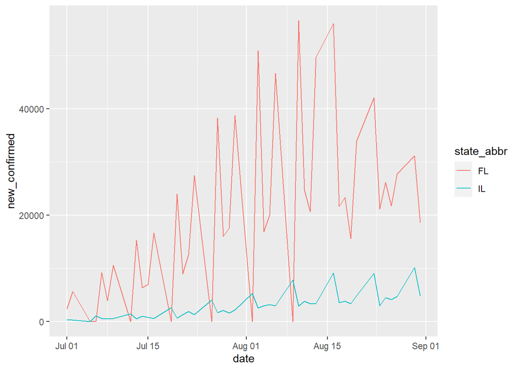

```r
ggplot(
  covid_sub,
  aes(x = date, y = new_confirmed, color = state_abbr)
  ) +
  geom_line()
```

Florida has significantly more covid cases than Illinois in the months of July and August 2021. The spikes to 0 could indicate testing did not occur on those days. Illinois has a positive “fairly linear” trend. Florida has a nonlinear trend where cases are increasing until around August 15th, at which point cases start to decrease.

**?@exr-ch02-app2**

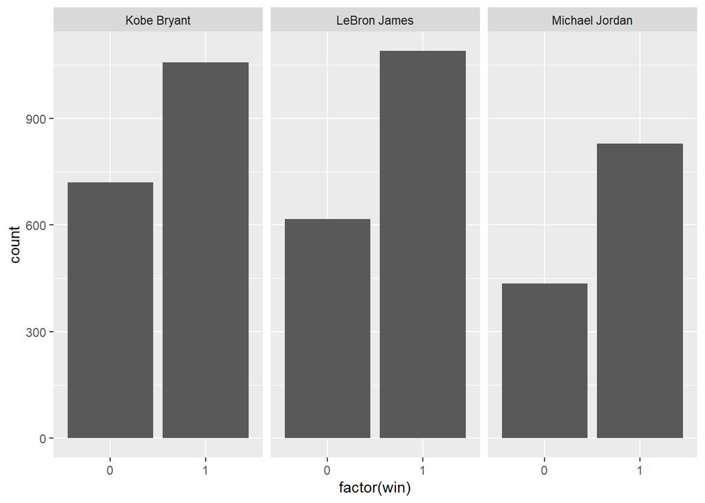

```r
ggplot(nba, aes(x = factor(win)) ) +
  geom_bar() +
  facet_wrap(~ player)
```

A win is indicated with a “1”. All three players have more wins than losses. LeBron has the most total wins and Jordan has the least total losses. But Jordan having less wins and losses is relative because he also played the least number of games.

**?@exr-ch02-app3**

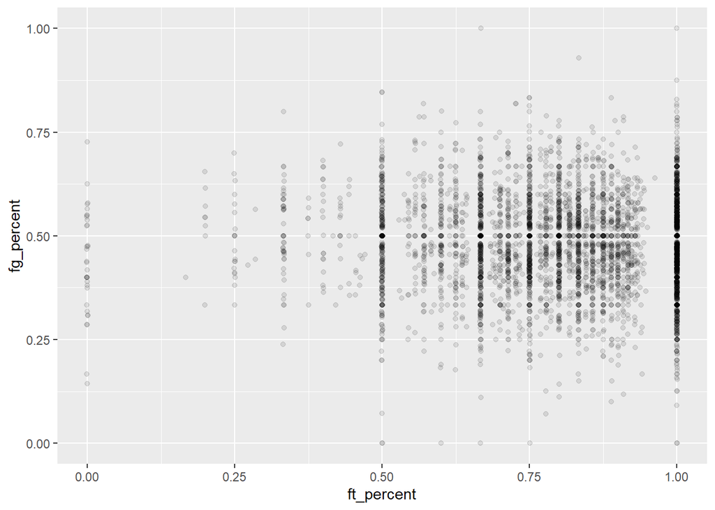

```r
ggplot(nba, aes(x = ft_percent, y = fg_percent)) +
  geom_jitter(alpha=0.1)
```

The relationship between the field goal percentage and free throw percentage seems to have no association. This means that whether a player made all of their free throws or only 50% of their free throws, it will not impact their shooting during the game (field goal percent). If we draw a circle around the points it is fairly horizontal (indicating no positive or negative trend) and a large oval.

**?@exr-ch02-app4**

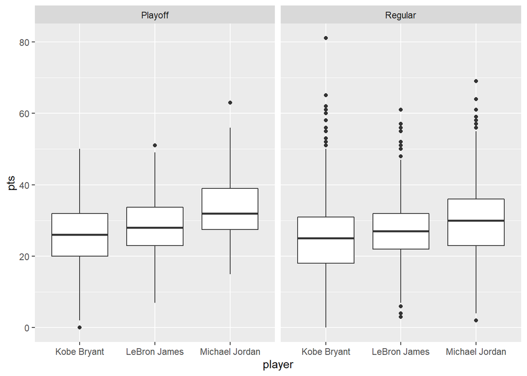

```r
ggplot(nba, aes(x = player, y = pts)) +
  geom_boxplot() +
  facet_wrap(~ season)
```

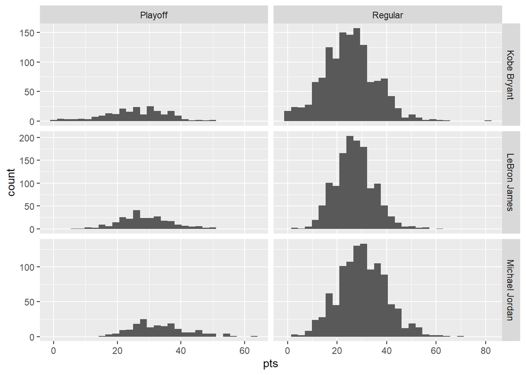

```r
#Alternate way to visualize
ggplot(nba, aes(x = pts)) +
  geom_histogram() +
  facet_grid(player ~ season, scales = "free")
```

**?@exr-ch02-adv1**

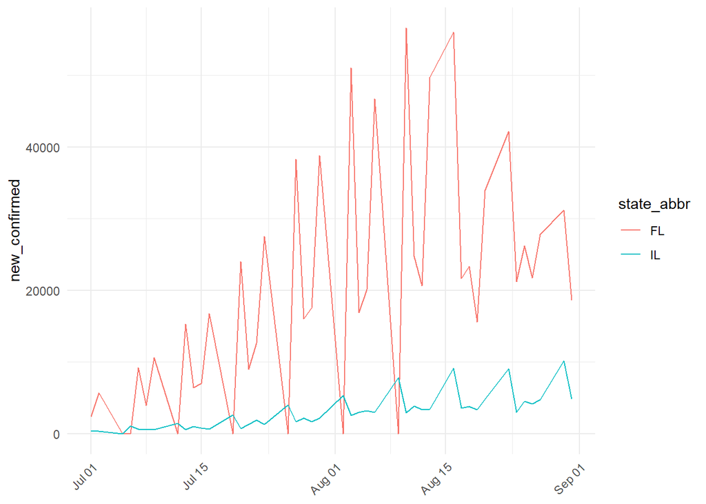

```r
ggplot(
  covid_sub,
  aes(x = date, y = new_confirmed, color = state_abbr)
  ) +
  geom_line() +
  theme_minimal() +
  labs(x = NULL) +
  theme(axis.text.x = element_text(angle = 45, hjust = 1))
```

## Chapter 3

**?@exr-ch03-c01** c. `x %>% c() %>% b() %>% a()`

**?@exr-ch03-c02** d. `arrange()` , g. `filter()` , c. `mutate()`

**?@exr-ch03-c03** c. 1 row and 4 columns

**?@exr-ch03-c04** b. To make exploring a data frame easier by only outputting the variables of interest

**?@exr-ch03-c05** a. increase

**?@exr-ch03-c06** c. median and interquartile range; mean and standard deviation

**?@exr-ch03-c07** b. $mean < median$

**?@exr-ch03-c08** a. These key variables uniquely identify the observational units

**?@exr-ch03-c09** d.

**?@exr-ch03-c10** d.

**?@exr-ch03-c11** a. e. (there is no variable called `passenger`)

**?@exr-ch03-app1**

```r
library(ISDSdatasets)
```

```r
nba %>%
  group_by(player) %>%
  summarize(avg_ft= mean(ft, na.rm=TRUE))
```

```
# A tibble: 3 x 2
  player         avg_ft
  <chr>           <dbl>
1 Kobe Bryant      6.19
2 LeBron James     5.92
3 Michael Jordan   7.03
```

**?@exr-ch03-app2**

```r
nba %>%
  group_by(player) %>%
  mutate(spread = pts_tm - pts_opp ) %>%
  ungroup() %>%
  slice_max(spread) %>%
  select(player, pts_tm, pts_opp, spread)
```

```
# A tibble: 1 x 4
  player      pts_tm pts_opp spread
  <chr>        <dbl>   <dbl>  <dbl>
1 Kobe Bryant    112      57     55
```

```r
# Alternate code
nba_spread <- nba %>%
  group_by(player) %>%
  mutate(spread = pts_tm - pts_opp ) %>%
  select(player, pts_tm, pts_opp, spread)

nba_spread %>% arrange(desc(spread))
```

```
# A tibble: 4,747 x 4
# Groups:   player [3]
   player         pts_tm pts_opp spread
   <chr>           <dbl>   <dbl>  <dbl>
 1 Kobe Bryant       112      57     55
 2 Michael Jordan    129      82     47
 3 Kobe Bryant       113      67     46
 4 Kobe Bryant       113      67     46
 5 Michael Jordan    114      69     45
 6 Michael Jordan    140      96     44
 7 LeBron James      130      86     44
 8 Michael Jordan    123      81     42
 9 Michael Jordan    111      69     42
10 Michael Jordan     96      54     42
# ... with 4,737 more rows
```

Kobe Bryant had the largest win spread, winning the game by 55 points.

**?@exr-ch03-app3**

```r
titanic %>%
  group_by(Pclass) %>%
  summarize(fare_calc= sum(Fare, na.rm=TRUE)) %>%
  arrange(desc(fare_calc))
```

```
# A tibble: 3 x 2
  Pclass fare_calc
   <dbl>     <dbl>
1      1    10088.
2      3     2704.
3      2     2065.
```

**?@exr-ch03-app4**

```r
covid_join <- covid_states %>%
 group_by(location_key, state) %>%
 summarize(total_new_confirmed=sum(new_confirmed, na.rm=TRUE),
           total_new_deceased=sum(new_deceased, na.rm=TRUE),
           total_new_recovered=sum(new_recovered, na.rm=TRUE),
           total_new_tested=sum(new_tested, na.rm=TRUE))

covid_joined <- covid_join %>%
  inner_join(covid_dem, by= "location_key")

covid_joined
```

```
# A tibble: 59 x 18
# Groups:   location_key [59]
   locat~1 state total~2 total~3 total~4 total~5 popul~6 popul~7 popul~8 popul~9
   <chr>   <chr>   <dbl>   <dbl>   <dbl>   <dbl>   <dbl>   <dbl>   <dbl>   <dbl>
 1 US_AK   Alas~  2.80e5    1316    7136  4.11e6  7.33e5  4.25e5  3.92e5  115198
 2 US_AL   Alab~  1.47e6   20047  287739  2.32e6  5.02e6  2.51e6  2.68e6  621981
 3 US_AR   Arka~  9.24e5   11861  315506  2.74e6  3.01e6  1.59e6  1.65e6  411655
 4 US_AS   Amer~  8.04e3      33       0  2.14e3  4.97e4 NA      NA           NA
 5 US_AZ   Ariz~  2.24e6   30982       0  7.91e6  7.15e6  4.03e6  4.09e6 1080975
 6 US_CA   Cali~  1.02e7   93827       0  1.82e8  3.95e7  2.05e7  2.09e7 5297960
 7 US_CA_~ Cali~  2.21e5       0       0  4.40e6  8.74e5  4.22e5  4.14e5   61427
 8 US_CO   Colo~  1.63e6   13235       0  6.42e6  5.77e6  2.98e6  2.98e6  782811
 9 US_CT   Conn~  8.69e5   11180    5454  6.52e6  3.61e6  1.82e6  1.93e6  416756
10 US_DC   Dist~  1.37e5    1377   34968  1.26e6  6.90e5  2.97e5  3.35e5   58373
# ... with 49 more rows, 8 more variables: population_age_10_19 <dbl>,
#   population_age_20_29 <dbl>, population_age_30_39 <dbl>,
#   population_age_40_49 <dbl>, population_age_50_59 <dbl>,
#   population_age_60_69 <dbl>, population_age_70_79 <dbl>,
#   population_age_80_and_older <dbl>, and abbreviated variable names
#   1: location_key, 2: total_new_confirmed, 3: total_new_deceased,
#   4: total_new_recovered, 5: total_new_tested, 6: population, ...
```

**?@exr-ch03-adv1**

```r
covid_pop <- covid_states %>%
  filter(state_abbr %in% c("CA", "TX", "FL", "NY"))
```

**?@exr-ch03-adv2**

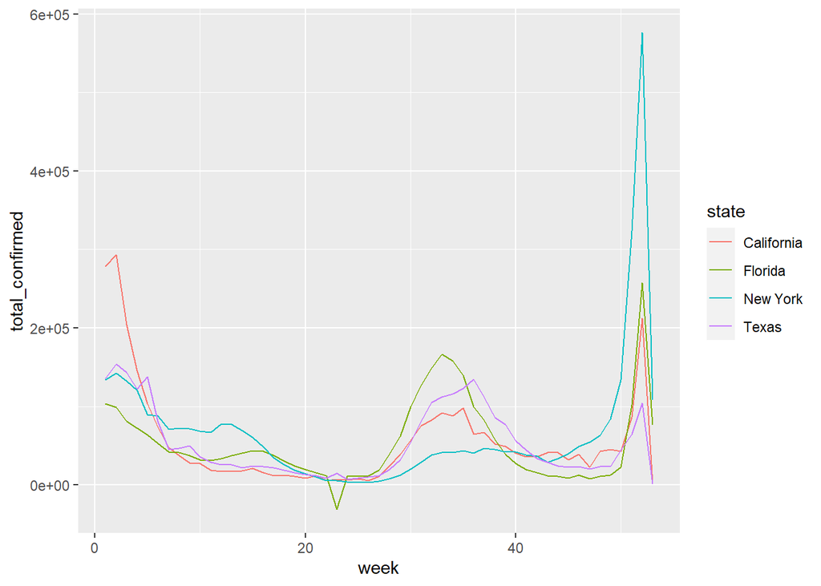

```r
library(lubridate)
covid_confirmed <- covid_pop %>%
  filter(date<="2021-12-31", date>="2021-01-01") %>%
  mutate(week = week(date)) %>%
  group_by(week, state) %>%
  summarize(total_confirmed = sum(new_confirmed))

ggplot(data=covid_confirmed,
       aes(x=week, y=total_confirmed, color=state)) +
  geom_line()
```

The linegraph shows that the states had the similar pattern overall. The peaks seem to correspond to weeks of holidays and school starting where people are gathering.

## Chapter 4

**Under Construction**

Currently working on exercise solutions.

## Chapter 5

**?@exr-ch05-c01** c) -0.7

**?@exr-ch05-c02** e) Exactly 1

**?@exr-ch05-c03** b) Between -1 and 0

**?@exr-ch05-c04** a) explanatory variable & d) independent variable

**?@exr-ch05-c05** b) predictor variable & c) outcome variable & e) dependent variable

**?@exr-ch05-c06** c) $b_0$ & e) the value of $\hat{y}$ when $x=0$ & f) intercept

**?@exr-ch05-c07** d) For every increase of 1 unit in x, there is an associated increase of, on average, 3.86 units of y.

**?@exr-ch05-c08** a) TRUE

**?@exr-ch05-c09** b) FALSE

**?@exr-ch05-c10** a) TRUE

**?@exr-ch05-c11** d) No, the positive correlation does not necessarily imply causation.

**?@exr-ch05-app1**

**a)**

```r
skim(covid_states)
```

Data summary

| Name | covid_states |
| --- | --- |
| Number of rows | 55520 |
| Number of columns | 14 |
| _______________________ |  |
| Column type frequency: |  |
| character | 5 |
| Date | 1 |
| numeric | 8 |
| ________________________ |  |
| Group variables | None |

**Variable type: character**

| skim_variable | n_missing | complete_rate | min | max | empty | n_unique | whitespace |
| --- | --- | --- | --- | --- | --- | --- | --- |
| location_key | 0 | 1 | 5 | 9 | 0 | 59 | 0 |
| country_code | 0 | 1 | 2 | 2 | 0 | 1 | 0 |
| state_abbr | 0 | 1 | 2 | 2 | 0 | 56 | 0 |
| state | 0 | 1 | 4 | 24 | 0 | 56 | 0 |
| wday | 0 | 1 | 3 | 3 | 0 | 7 | 0 |

**Variable type: Date**

| skim_variable | n_missing | complete_rate | min | max | median | n_unique |
| --- | --- | --- | --- | --- | --- | --- |
| date | 0 | 1 | 2020-01-13 | 2022-12-30 | 2021-05-07 | 954 |

**Variable type: numeric**

| skim_variable | n_missing | complete_rate | mean | sd | p0 | p25 | p50 | p75 | p100 | hist |
| --- | --- | --- | --- | --- | --- | --- | --- | --- | --- | --- |
| new_confirmed | 0 | 1.00 | 1725.63 | 5649.36 | -53831 | 9.0 | 346 | 1433.0 | 319809 | ▇▁▁▁▁ |
| new_deceased | 901 | 0.98 | 19.59 | 57.18 | -3770 | 0.0 | 3 | 17.0 | 2559 | ▁▁▇▂▁ |
| new_recovered | 43274 | 0.22 | 879.41 | 4938.94 | -315000 | 1.0 | 69 | 617.0 | 315000 | ▁▁▇▁▁ |
| new_tested | 32479 | 0.42 | 21769.69 | 53758.08 | -130545 | 1158.0 | 5884 | 18827.0 | 871290 | ▇▁▁▁▁ |
| cumulative_confirmed | 1 | 1.00 | 628873.85 | 1100381.55 | 0 | 28294.5 | 222594 | 766512.0 | 10987530 | ▇▁▁▁▁ |
| cumulative_deceased | 909 | 0.98 | 9539.52 | 14851.62 | 0 | 545.0 | 3438 | 12193.0 | 94571 | ▇▁▁▁▁ |
| cumulative_recovered | 43240 | 0.22 | 92909.01 | 208847.73 | 2 | 3541.0 | 19740 | 91010.5 | 2502609 | ▇▁▁▁▁ |
| cumulative_tested | 32641 | 0.41 | 4816529.00 | 18803996.33 | 0 | 124268.5 | 743851 | 2663914.0 | 181621431 | ▇▁▁▁▁ |

**b)**

```r
covid_states %>%
  select(new_tested, new_confirmed) %>%
  cor(use = "complete.obs")
```

```
              new_tested new_confirmed
new_tested     1.0000000     0.5143968
new_confirmed  0.5143968     1.0000000
```

The correlation is 0.514.

**c)**

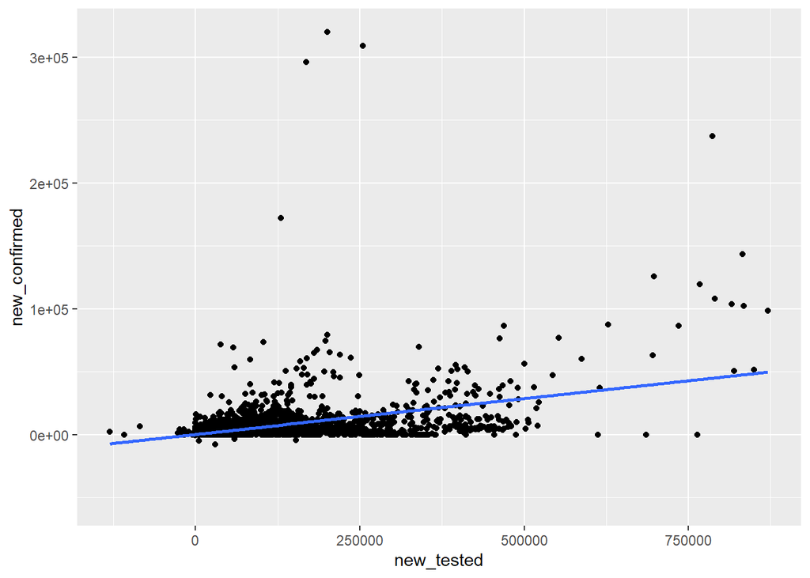

```r
ggplot(covid_states, aes(x = new_tested, y = new_confirmed)) +
  geom_point() +
  geom_smooth(method = "lm", se = FALSE)
```

**d)**

```r
model_covid <- lm(new_confirmed ~ new_tested, data = covid_states)

summary(model_covid)$coefficients
```

```
                Estimate   Std. Error   t value     Pr(>|t|)
(Intercept) 320.15752670 3.623722e+01  8.835047 1.070594e-18
new_tested    0.05688714 6.248052e-04 91.047802 0.000000e+00
```

$$\widehat{newconfirmed} = 320.16 + 0.057*newtested$$
**e)**

**Intercept**: When there are 0 people newly tested for COVID, we expect there to 320.16 newly confirmed cases.

**Slope:**: For every 1 additional person newly tested for COVID, we expect the number of new confirmed cases to increase by 0.057.

**f)**

```r
320.16 + 0.057*20000
```

```
[1] 1460.16
```

We would expect 1,460 people to have COVID.

**?@exr-ch05-app2**

```r
model_pts <- lm(pts_tm ~ pts, data = nba)

summary(model_pts)
```

```
Call:
lm(formula = pts_tm ~ pts, data = nba)

Residuals:
    Min      1Q  Median      3Q     Max
-41.117  -8.288  -0.497   7.813  52.883

Coefficients:
            Estimate Std. Error t value Pr(>|t|)
(Intercept) 92.80431    0.53661  172.95   <2e-16 ***
pts          0.34493    0.01844   18.71   <2e-16 ***
---
Signif. codes:  0 '***' 0.001 '**' 0.01 '*' 0.05 '.' 0.1 ' ' 1

Residual standard error: 11.84 on 4391 degrees of freedom
  (354 observations deleted due to missingness)
Multiple R-squared:  0.07382,   Adjusted R-squared:  0.0736
F-statistic:   350 on 1 and 4391 DF,  p-value: < 2.2e-16
```

**a)** 0.272

```r
nba %>%
  summarize(cor = cor(pts_tm, pts, use = "complete.obs"))
```

```
# A tibble: 1 x 1
    cor
  <dbl>
1 0.272
```

**b)**

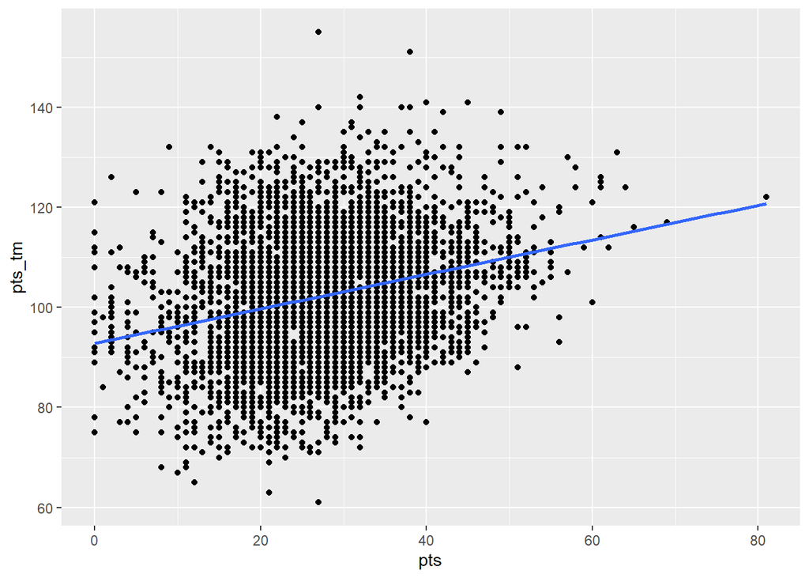

```r
ggplot(nba, aes(x = pts, y = pts_tm)) +
  geom_point() +
  geom_smooth(method = "lm", se = FALSE)
```

**c)**
$$\widehat{pts tm} = 92.80 + 0.345*pts$$
**d)**

**Intercept**: When the individual player scored 0 points in a game, we expect their team to score 92.80 points.

**Slope:**: For every 1 additional point the individual player scores, we expect the number of total points the team scores to increase by 0.345.

**e)** We predict the team will have a total of 110 points.

```r
92.80 + 0.345*50
```

```
[1] 110.05
```

**?@exr-ch05-app3**

```r
model_fare <- lm(Fare ~ Embarked, data = titanic)

summary(model_fare)$coefficients
```

```
             Estimate Std. Error   t value     Pr(>|t|)
(Intercept)  66.25976   5.245351 12.632094 3.631118e-31
EmbarkedQ   -55.30206   9.408632 -5.877801 8.563720e-09
EmbarkedS   -38.02933   6.160066 -6.173526 1.594559e-09
```

**b)** The expected fare for passengers that embarked from Cherbourg (C) is 66.26.

**c)** On average, Cherbourg (C) had the highest ticket cost.

**d)**

```r
titanic_error <- titanic %>%
  filter(!is.na(Fare)) %>%
  mutate(residuals = residuals(model_fare),
         fitted = fitted.values(model_fare)) %>%
  select(PassengerId, Survived, Fare,
         Embarked, residuals, fitted)

titanic_error %>%
  slice_max(residuals, n=1)
```

```
# A tibble: 1 x 6
  PassengerId Survived  Fare Embarked residuals fitted
        <dbl>    <dbl> <dbl> <chr>        <dbl>  <dbl>
1        1235        1  512. C             446.   66.3
```

```r
titanic_error %>%
  slice_min(residuals, n=1)
```

```
# A tibble: 2 x 6
  PassengerId Survived  Fare Embarked residuals fitted
        <dbl>    <dbl> <dbl> <chr>        <dbl>  <dbl>
1        1008        0  6.44 C            -59.8   66.3
2        1025        0  6.44 C            -59.8   66.3
```

The worst prediction will be the residual that is farthest from 0. We checked both the min (farthest negative) and max (farthest positive) residual. Passenger 1235 had the worst prediction with an observed value of 512.33 and predicted value of 66.26 (residual of 446.07).

**?@exr-ch05-adv1**

```r
# coefficients
summary(model_pts)$coefficients
```

```
              Estimate Std. Error   t value     Pr(>|t|)
(Intercept) 92.8043115 0.53660781 172.94626 0.000000e+00
pts          0.3449292 0.01843843  18.70708 3.387935e-75
```

```r
# or
model_pts$coefficients
```

```
(Intercept)         pts
 92.8043115   0.3449292
```

```r
# r.squared
summary(model_pts)$r.squared
```

```
[1] 0.07381528
```

## Chapter 6

**?@exr-ch06-c01** c. The parallel slopes model. Since two models are very similar, the additional complexity of the interaction model isn’t necessary

**?@exr-ch06-c02** d. 0.47

**?@exr-ch06-c03** b. False

**?@exr-ch06-c04** a. True

**?@exr-ch06-c05** a. Splitting up your data can result in unequal balance in representation of some groups compared to others. & d. Splitting up your data by a confounding variable can allow you to see trends in the data that were hidden in the aggregated version of the data.

**?@exr-ch06-app1**

```r
covid_pred <- lm(new_confirmed ~ new_recovered + new_deceased, data = covid_states)

summary(covid_pred)$coefficients
```

```
                  Estimate   Std. Error  t value      Pr(>|t|)
(Intercept)   518.74700904 18.288027150 28.36539 1.772179e-171
new_recovered   0.08351059  0.003615216 23.09975 1.353691e-115
new_deceased   26.48933330  0.380325510 69.64911  0.000000e+00
```

**?@exr-ch06-app2**

```r
covid_merge <- covid_states %>%
  left_join(covid_dem)

covid_pred2 <- lm(new_confirmed ~ population + new_tested,
                  data = covid_merge)

summary(covid_pred2)$coefficients
```

```
                Estimate   Std. Error   t value     Pr(>|t|)
(Intercept) 1.704474e+02 4.211070e+01  4.047604 5.191359e-05
population  3.711377e-05 5.333525e-06  6.958581 3.529293e-12
new_tested  5.272425e-02 8.645625e-04 60.983732 0.000000e+00
```

**?@exr-ch06-app3**

```r
model_pts_parallel <- lm(pts_tm ~ pts + location,
                   data = nba)

summary(model_pts_parallel)$coefficients
```

```
               Estimate Std. Error   t value     Pr(>|t|)
(Intercept)  90.9083513 0.55936120 162.52173 0.000000e+00
pts           0.3454997 0.01820944  18.97366 3.212988e-77
locationHome  3.7359444 0.35274866  10.59095 6.723724e-26
```

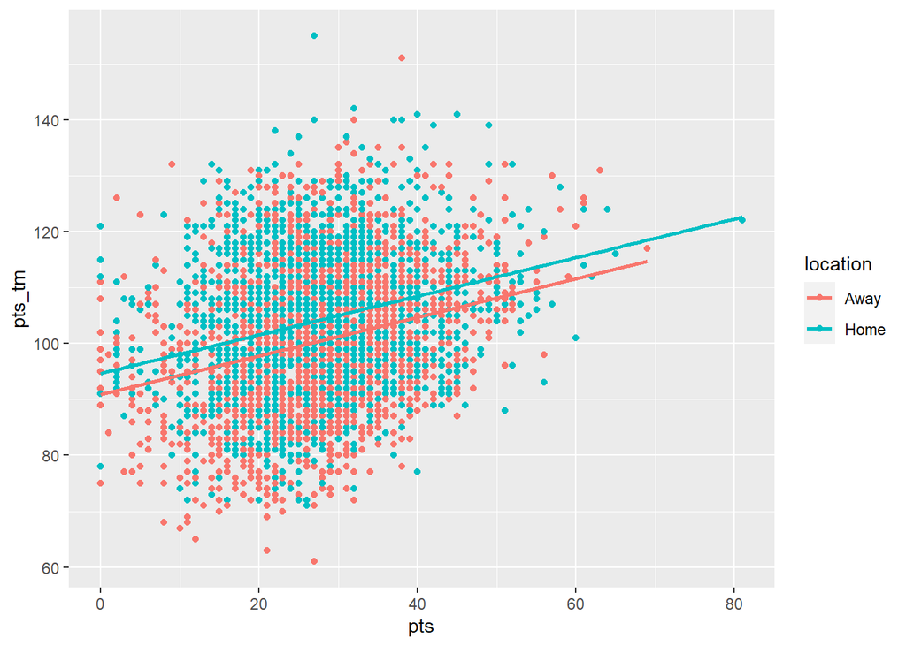

```r
ggplot(nba, aes(x = pts, y = pts_tm, color = location)) +
  geom_point() +
  geom_parallel_slopes(se = FALSE)
```

**b_0** When the star player scores 0 points and the game is away, the team is predicted to score 90.9 points.

**b_1** For every additional point the star player scores, the associated expected increase in team points is 0.345, regardless if the game is home or away.

**b_2** The team is expected to score on average 3.74 more points when the game is home compared to when the game is away.

**?@exr-ch06-app4**

```r
model_pts_int <- lm(pts_tm ~ pts*location,
                   data = nba)

summary(model_pts_int)$coefficients
```

```
                   Estimate Std. Error    t value     Pr(>|t|)
(Intercept)      88.5705162 0.75138008 117.877115 0.000000e+00
pts               0.4305969 0.02579626  16.692224 1.072315e-60
locationHome      8.3693493 1.05745823   7.914591 3.117298e-15
pts:locationHome -0.1688308 0.03633496  -4.646510 3.474887e-06
```

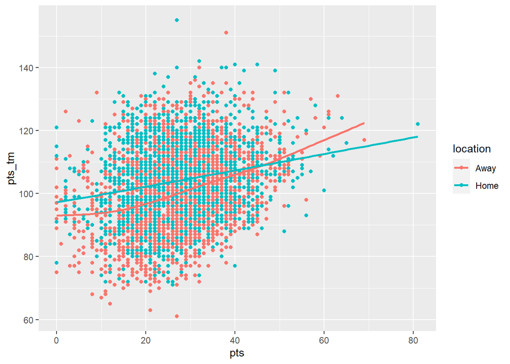

```r
ggplot(nba, aes(x = pts, y = pts_tm, color = location)) +
  geom_point() +
  geom_smooth(se = FALSE)
```

**b_0** When the star player scores 0 points and the game is away, the team is predicted to score 88.57 points.

**b_1** For every additional point the star player scores, the associated expected increase in team points is 0.431 for away games.

**b_2** When the star player scores 0 points, the team is expected to score on average 8.37 more points when the game is home compared to when the game is away.

**b_3** For every additional point the star player scores, the associated expected increase in team points will be 0.169 less for home games than away games.

**?@exr-ch06-adv1**

```r
# parallel slopes
mean(model_pts_parallel$residuals^2)
```

```
[1] 136.5566
```

```r
# interaction
mean(model_pts_int$residuals^2)
```

```
[1] 135.8881
```

The MSE of the parallel slopes is 136.6 and the MSE of the interaction is 135.9. Since the MSE for the interaction model is smaller it appears to be slightly better.

**?@exr-ch06-adv2**

**Many different possible answers**

```r
model_better <- lm(pts_tm ~ pts_opp + pts, data = nba)

mean(model_better$residuals^2)
```

```
[1] 116.9488
```

This model which uses the opponents points and star player points has an MSE of 116.9 which is better.

## Chapter 7

**?@exr-ch07-c01** a) There is a non-zero probability of being selected into the treatment or control group for every unit & c) A random process is used for selection & e) A random process is used for administration of the treatments

**?@exr-ch07-c02** d) rbernoulli(n = 1000, p = 0.25)

**?@exr-ch07-c03** b) False

**?@exr-ch07-c04** a) True

**?@exr-ch07-c05** a) Try to ensure that treatment and control groups are as similar as possible on all variables related to treatment assignment & c) Look for variables you can use to control for confounding & d) State your assumptions and limitations

**?@exr-ch07-c06** b) private colleges are only correlated with higher GPAs, because this would be an observational study

**?@exr-ch07-c07** b) video games are only correlated with violent behavior, because this would be an observational study

**?@exr-ch07-c08** Perhaps class size is a confounding variable for gpa, smaller sizes could lead to more individualized attention and higher grades. Perhaps parental control is a confounding variable for video games, children that play violent video games probably have less parental guidance or household rules leading to poor behavior choices.

**?@exr-ch07-c09** d) No, because the treatment and control groups were not randomized

**?@exr-ch07-c10** a confounding (or lurking) variable

**?@exr-ch07-app1** No the administration cannot conclude the after-school program caused student improvement. While this was a randomized selection of a subset of students we cannot generalize to all students because all students were not considered. Also, this was a before and after study where it is likely the material from the fall semester is likely different from the material in the spring semester. Perhaps these students were just better at the topics covered in the spring.

**?@exr-ch07-app2** Geography might impact the results because maybe the west has more rural cities than the east or perhaps there are different demographics of people that live in each region. Certain types of people/demographics might favor the ‘traditional’ label and deter from the new label because they don’t recognize it while other types of people will see the new label and but it because it is ‘new’. A way to reduce the impact of geography is to use “matching”. Find a list of cities in the east that match on average with the cities in the west (perhaps New York City is very similar on average to Los Angeles etc.). Then randomly sample these pairs of cities to compare sales results (to measure if it is receptive).

## Chapter 8

**?@exr-ch08-c01** d) a population parameter

**?@exr-ch08-c02** b) $\hat{\mu}$ & d) $\bar{x}$ & f) $\hat{\pi}$ & g) $p$ & h) $\hat{p}$ & i) $s$ & k) $\hat{\sigma}$

**?@exr-ch08-c03** all of them (a, b, c, d)

**?@exr-ch08-c04** b) Cluster sampling

**?@exr-ch08-c05** d) Systematic sampling

**?@exr-ch08-c06** c) Stratified sampling

**?@exr-ch08-c07** c) Cluster sampling (with unequal probability) choosing towns is based on random cluster selection

**?@exr-ch08-c08** b) False

**?@exr-ch08-c09** c) An observational study with random sampling but no random assignment

**?@exr-ch08-c10** d) No, you cannot make causal or generalizable claims from the results of your survey

**?@exr-ch08-app1** population: US citizens

parameter: proportion (most likely a Yes or No question)

undercoverage: citizens that do not own a house, if there are multiple citizens in one household only one person will receive the survey.

**?@exr-ch08-app2**

sampling method: stratified sampling

Compared to simple random sampling, stratified sample is guaranteed to represent people from all 50 states.

While the stratified sampling would allow for better representation of people in different states, the same limitations in regards to citizens without addresses or if multiple citizens live in one household.

## Chapter 9